# STAT 380 Final Project

April 30, 2025

## Front Matter

```r
#Remove all objects from Environment
remove(list = ls())

#Load packages
library(tidyverse)
library(rpart) #For regression and classification trees
library(rattle) #For nice visualization of trees
library(kableExtra)
library(broom)
library(caret)
library(randomForest)
library(class)
library(ggpubr)
library(broom)
library(emmeans)
library(patchwork)
library(fuzzyjoin) # For next step clean typo
library(e1071)
#Read in Dataset
# Jackie Yang
CODGames_p1_380 <- read.csv("C:/ESSENTIALS/School OS/Junior Spring 2025/STAT 380/Datasets/CODGames_p1_380.csv")
CODGames_p2_380 <- read.csv("C:/ESSENTIALS/School OS/Junior Spring 2025/STAT 380/Datasets/CODGames_p2_380.csv")
CODMaps <- read.csv("C:/ESSENTIALS/School OS/Junior Spring 2025/STAT 380/Datasets/CODMaps.csv")



# Xinyu Xie
#CODGames_p1_380 <- read.csv("CODGames_p1_380.csv")
#CODGames_p2_380 <- read.csv("CODGames_p2_380.csv")
#CODMaps <- read.csv("CODMaps.csv")


head(CODGames_p1_380)
```

```
##                Map1         Map2            Choice MapVote   Date FullPartial
## 1            Moscow Miami Strike      Miami Strike  5 to 0 6/6/22        Full
## 2            Moscow          WMD            Moscow  2 to 0 6/6/22        Full
## 3                                         Yamantau         6/6/22        Full
## 4          Drive-In       Jungle          Drive-In  2 to 0 6/6/22        Full
## 5 Collateral Strike     Hijacked Collateral Strike  3 to 3 6/6/22        Full
## 6 Crossroads Strike         Raid              Raid  4 to 3 6/6/22        Full
##   Result Eliminations Deaths Score Damage TotalXP PrimaryWeapon          XPType
## 1 100-97           22     17  4070    634   11002           M16       10% Boost
## 2  76-89           20     15  5305    560    9451           M16       10% Boost
## 3 100-92           18     11  3335    483   12948           M16       10% Boost
## 4 80-100           10     19  2170    280   11502           M16 Double XP + 10%
## 5 71-100           11     19  2195    308   11133           M16 Double XP + 10%
## 6 85-100            7     18   850    196   10077           M16 Double XP + 10%
##   DidPlayerVote GameType Confirms Denies Objectives ObjectiveKills Captures
## 1            No HC - TDM       NA     NA         NA             NA       NA
## 2            No HC - TDM       NA     NA         NA             NA       NA
## 3            No HC - TDM       NA     NA         NA             NA       NA
## 4            No HC - TDM       NA     NA         NA             NA       NA
## 5            No HC - TDM       NA     NA         NA             NA       NA
## 6            No HC - TDM       NA     NA         NA             NA       NA
##   Diffuses Plants Detonates Deposits Time_Sec Time_Min
## 1       NA     NA        NA       NA       NA       NA
## 2       NA     NA        NA       NA       NA       NA
## 3       NA     NA        NA       NA       NA       NA
## 4       NA     NA        NA       NA       NA       NA
## 5       NA     NA        NA       NA       NA       NA
## 6       NA     NA        NA       NA       NA       NA
```

```r
head(CODGames_p2_380)
```

```
##                Map1              Map2            Choice MapVote     Date
## 1          Yamantau Collateral Strike Collateral Strike  2 to 1 12/11/21
## 2         Deprogram            Cartel         Deprogram  2 to 2 12/11/21
## 3          Yamantau      Miami Strike          Yamantau  0 to 0 12/11/21
## 4                                               Amerika         12/11/21
## 5            Moscow          Drive-In            Moscow  1 to 0 12/11/21
## 6 Crossroads Strike           Express           Express  2 to 1 12/11/21
##   FullPartial  Result Eliminations Deaths Score Damage TotalXP PrimaryWeapon
## 1        Full 189-250           22     25  3705    576   11699         MG 82
## 2        Full 202-250           20     25  2560    524   16068         MG 82
## 3        Full  250-11            7      5  1875    182   13194         MG 82
## 4        Full 250-202           15     24  2405    383   19936         MG 82
## 5        Full 224-250           22     30  2520    567   19138         MG 82
## 6        Full 250-165           24     16  3810    673   25559         MG 82
##            XPType DidPlayerVote       GameType Confirms Denies Objectives
## 1       10% Boost            No HC - Hardpoint       NA     NA         NA
## 2 Double XP + 10%            No HC - Hardpoint       NA     NA         NA
## 3 Double XP + 10%            No HC - Hardpoint       NA     NA         NA
## 4 Double XP + 10%            No HC - Hardpoint       NA     NA         NA
## 5 Double XP + 10%            No HC - Hardpoint       NA     NA         NA
## 6 Double XP + 10%            No HC - Hardpoint       NA     NA         NA
##   ObjectiveKills Captures Diffuses Plants Detonates Deposits Time_Sec Time_Min
## 1              9       NA       NA     NA        NA       NA       57        1
## 2              8       NA       NA     NA        NA       NA       35        1
## 3              4       NA       NA     NA        NA       NA        8        2
## 4              1       NA       NA     NA        NA       NA       40        1
## 5             14       NA       NA     NA        NA       NA        4        1
## 6              6       NA       NA     NA        NA       NA        4        1
```

# Task 1 (Data Cleaning and Data Visualization – Complete without Generative AI)

## Research Question: Which maps are the most likely to win the map vote when they are an option?

## Plan

To address this research question, we set up some steps.

Step 1 Data Wrangling: The two parts of the dataset should be merged as per the requirement and then the contents of the dataset should be viewed. First, checking and resolving the quality issues present in the dataset and after that, creating a new variable `prob` for the probability of the map winningthe vote. We want to count the number of times each map is listed as a candidate map to win.

Step 2 Data Visualization: See which map won the most times and had the highest probability of winning by using two bar charts.

Step 3 Create an Aesthetically Pleasing Table: Show the number of times each map won and the probability of winning to draw conclusions about our research question.

## Step 1 Data Wrangling

```r
# Combine the dataset as require
CODGames <- rbind(CODGames_p1_380, CODGames_p2_380)
CODGames_T3 <- CODGames
#Check what kind of map name in the dataset
unique(CODGames$Choice)
```

```
##  [1] "Miami Strike"           "Moscow"                 "Yamantau"
##  [4] "Drive-In"               "Collateral Strike"      "Raid"
##  [7] "WMD"                    "Standoff"               "Crossroads Strike"
## [10] "Deprogram"              "Nuketown '84"           "Jungle"
## [13] "Rush"                   "Zoo"                    "Slums"
## [16] "Echelon"                "Garrison"               "Cartel"
## [19] "Express"                "The Pines"              "Apocalypse"
## [22] "Diesel"                 "Amerika"                "Checkmate"
## [25] "Hijacked"               ""                       "Satellite"
## [28] "Miami"                  "Apocolypse"             "Armada Strike"
## [31] "Collateral"             "APocalypse"             "Drive-in"
## [34] "Collaterel Strike"      "Nuketown '84 Halloween" "Deisel"
## [37] "Riad"
```

```r
# Using CODMaps names, we clean the data set
CODGames <- CODGames %>%
  mutate(Choice = ifelse(Choice == "APocalypse", "Apocalypse", Choice))%>%
  mutate(Choice = ifelse(Choice == "Apocolypse", "Apocalypse", Choice))%>%
  mutate(Choice = ifelse(Choice == "Drive-in", "Drive-In", Choice))%>%
  mutate(Choice = ifelse(Choice == "Deisel", "Diesel", Choice))%>%
  mutate(Choice = ifelse(Choice == "Riad", "Raid", Choice))%>%
  mutate(Choice = ifelse(Choice == "Collateral", "Collateral Strike", Choice))%>%
  mutate(Choice = ifelse(Choice == "Collaterel Strike", "Collateral Strike", Choice))%>%
  mutate(Choice = ifelse(Choice == "Nuketown '84 Halloween", "Nuketown '84", Choice))%>%
  mutate(Choice = ifelse(Choice == "Nuketown '84 Halloween", "Nuketown '84", Choice))%>%
  mutate(Map1 = ifelse(Map1 == "APocalypse", "Apocalypse", Map1))%>%
  mutate(Map1 = ifelse(Map1 == "Apocolypse", "Apocalypse", Map1))%>%
  mutate(Map1 = ifelse(Map1 == "Drive-in", "Drive-In", Map1))%>%
  mutate(Map1 = ifelse(Map1 == "Deisel", "Diesel", Map1))%>%
  mutate(Map1 = ifelse(Map1 == "Riad", "Raid", Map1))%>%
  mutate(Map1 = ifelse(Map1 == "Collateral", "Collateral Strike", Map1))%>%
  mutate(Map1 = ifelse(Map1 == "Collaterel Strike", "Collateral Strike", Map1))%>%
  mutate(Map1 = ifelse(Map1 == "Nuketown '84 Halloween", "Nuketown '84", Map1))%>%
  mutate(Map1 = ifelse(Map1 == "Nuketown '84 Halloween", "Nuketown '84", Map1))%>%
  mutate(Map1 = ifelse(Map1 == "APocalypse", "Apocalypse", Map1))%>%
  mutate(Map2 = ifelse(Map2 == "Apocolypse", "Apocalypse", Map2))%>%
  mutate(Map2 = ifelse(Map2 == "Drive-in", "Drive-In", Map2))%>%
  mutate(Map2 = ifelse(Map2 == "Deisel", "Diesel", Map2))%>%
  mutate(Map2 = ifelse(Map2 == "Riad", "Raid", Map2))%>%
  mutate(Map2 = ifelse(Map2 == "Collateral", "Collateral Strike", Map2))%>%
  mutate(Map2 = ifelse(Map2 == "Collaterel Strike", "Collateral Strike", Map2))%>%
  mutate(Map2 = ifelse(Map2 == "Nuketown '84 Halloween", "Nuketown '84", Map2))%>%
  mutate(Map2 = ifelse(Map2 == "Nuketown '84 Halloween", "Nuketown '84", Map2))%>%
  mutate(across(c(Choice, Map1, Map2), ~ tolower(str_trim(.))))%>%
  filter(Map1 != "" & !is.na(Map1))%>%
  mutate(Map1 = ifelse(Map1 == "amrada strike", "armada strike", Map1))%>%
  mutate(Map2 = ifelse(Map2 == "amrada strike", "armada strike", Map2))%>%
  mutate(Map1 = ifelse(Map1 == "collaterol strike", "collateral strike", Map1))%>%
  mutate(Map2 = ifelse(Map2 == "collaterol strike", "collateral strike", Map2))%>%
  mutate(Map1 = ifelse(Map1 == "collateral striek", "collateral strike", Map1))%>%
  mutate(Map2 = ifelse(Map2 == "collateral striek", "collateral strike", Map2))%>%
  mutate(Map1 = ifelse(Map1 == "deprogam", "deprogram", Map1))%>%
  mutate(Map2 = ifelse(Map2 == "deprogam", "deprogram", Map2))%>%
  mutate(Map1 = ifelse(Map1 == "miami sstrike", "miami strike", Map1))%>%
  mutate(Map2 = ifelse(Map2 == "miami sstrike", "miami strike", Map2))%>%
  mutate(Map1 = ifelse(Map1 == "miami stirke", "miami strike", Map1))%>%
  mutate(Map2 = ifelse(Map2 == "miami stirke", "miami strike", Map2))%>%
  mutate(Map1 = ifelse(Map1 == "ruah", "rush", Map1))%>%
  mutate(Map2 = ifelse(Map2 == "ruah", "rush", Map2))%>%
  filter(!MapVote %in% c("0 to 0","1 to 1", "2 to 2", "3 to 3", "4 to 4"))

# Check again to make sure we did it correctly
unique(CODGames$Choice)
```

```
##  [1] "miami strike"      "moscow"            "drive-in"
##  [4] "raid"              "standoff"          "deprogram"
##  [7] "jungle"            "crossroads strike" "express"
## [10] "the pines"         "yamantau"          "rush"
## [13] "apocalypse"        "collateral strike" "slums"
## [16] "diesel"            "amerika"           "nuketown '84"
## [19] "zoo"               "checkmate"         "wmd"
## [22] "hijacked"          "echelon"           "garrison"
## [25] "cartel"            "satellite"         "miami"
## [28] "armada strike"
```

```r
#unique(CODGames$MapVote)
```

We looked at the dataset and found a total of 37 different map names. According to the `CODMap.csv` file we know that we should only have 28 different map names. We modified the wrong name and used mutate() to change the map name to the official name and filtered for missing values.

We checked the validity of our cleanup with *unique(CODGames$Choice)*, for now we have 28 kind of maps name, consist with *CODmaps.csv*.

We still need three new variables: the number of times a map appears, the number of times a map is won, and the percentage of wins for a map

```r
#
CODGames_count_choice <- CODGames %>%
  group_by(Choice)%>%
  summarize(N_Choice = n())

#
CODGames_count_showup <- CODGames  %>%
  pivot_longer(cols = c(Map1, Map2), names_to = "bind", values_to = "Show_up")%>%
  group_by(Show_up) %>%
  summarize(N_Show_up = n())

#
CODMaps <- CODMaps %>%
  mutate(across(c(Name), ~ tolower(str_trim(.)))) %>%
  full_join(CODGames_count_choice, by = c("Name" = "Choice")) %>%
  full_join(CODGames_count_showup, by = c("Name" = "Show_up"))


CODMaps <- CODMaps%>%
  mutate( picked_rate = N_Choice / N_Show_up)

#head(CODMaps)
```

## Step 2 Data visualization

### Bar Plot

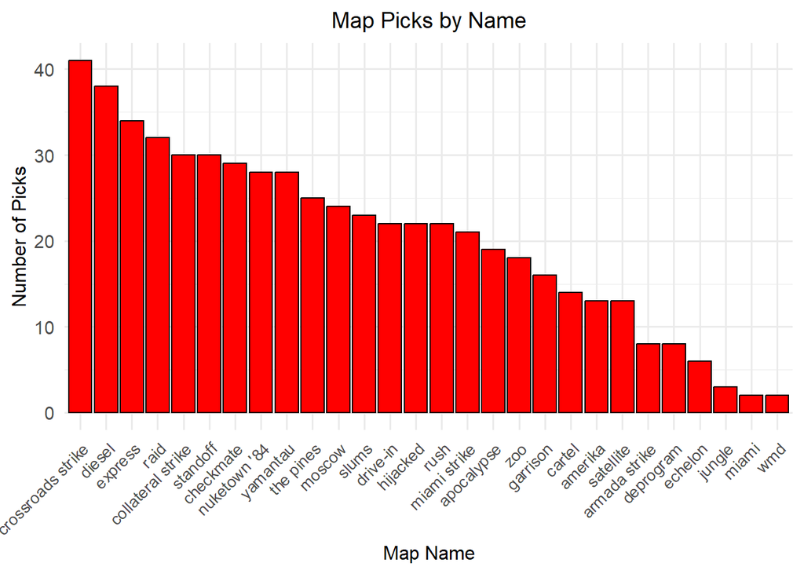

```r
# Bar plot
ggplot(data = CODMaps, aes(x = reorder(Name, -N_Choice), y = N_Choice)) +
  geom_bar(stat = "identity", fill = "red", color = "black") +
  theme_minimal(base_size = 14) +
  theme(
    axis.text.x = element_text(angle = 45, hjust = 1, size = 10),
    axis.title.x = element_text(size = 12),
    axis.title.y = element_text(size = 12),
    plot.title = element_text(hjust = 0.5, size = 14)
  ) +
  labs(
    x = "Map Name",
    y = "Number of Picks",
    title = "Map Picks by Name"
  )
```

According to the bar graph, we found that *Crossroads Strike* is selected most often, but this does not mean that this map is most likely to win the map vote because we can’t assume that every map has the same probability of appearing in a candidate position, and each map may have its own appearance weighting. We think this is often involved in game planning.

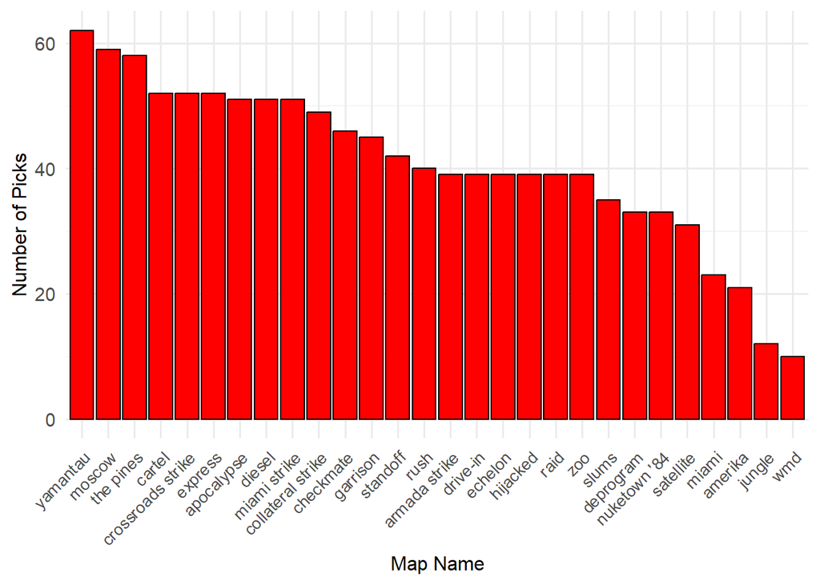

```r
# Bar plot
ggplot(data = CODMaps, aes(x = reorder(Name, -N_Show_up), y = N_Show_up)) +
  geom_bar(stat = "identity",fill = "red", color = "black") +
  theme_minimal(base_size = 14) +
  theme(axis.text.x = element_text(angle = 45, hjust = 1, size = 10),
    axis.title.x = element_text(size = 12),
    axis.title.y = element_text(size = 12),
    plot.title = element_text(hjust = 0.5, size = 14)) +
  labs(x = "Map Name",
       y = "Number of Picks")
```

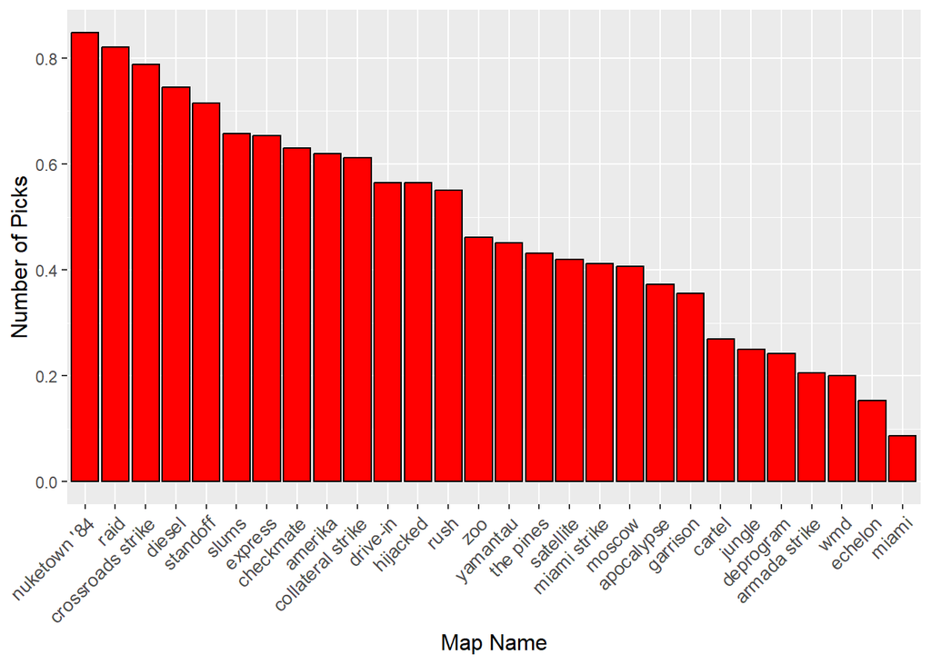

```r
# Bar plot
ggplot(data = CODMaps, aes(x = reorder(Name, -picked_rate), y = picked_rate)) +
  geom_bar(stat = "identity",fill = "red", color = "black") +
  theme(axis.text.x = element_text(angle = 45, hjust = 1, size = 10),
    axis.title.x = element_text(size = 12),
    axis.title.y = element_text(size = 12),
    plot.title = element_text(hjust = 0.5, size = 14)) +
  labs(x = "Map Name",
       y = "Number of Picks")
```

## Step 3 Table of Results

```r
CODMaps %>%
  dplyr::select(-FirstAvailable, -Date) %>%
  rename(`Candidate count` = N_Show_up, `Picked Count` = N_Choice , `Picked Rate` = picked_rate) %>%
  arrange(desc(`Picked Rate`)) %>%
  kbl() %>%
  kable_classic()
```

| Name | Picked Count | Candidate count | Picked Rate |
| --- | --- | --- | --- |
| nuketown ’84 | 28 | 33 | 0.8484848 |
| raid | 32 | 39 | 0.8205128 |
| crossroads strike | 41 | 52 | 0.7884615 |
| diesel | 38 | 51 | 0.7450980 |
| standoff | 30 | 42 | 0.7142857 |
| slums | 23 | 35 | 0.6571429 |
| express | 34 | 52 | 0.6538462 |
| checkmate | 29 | 46 | 0.6304348 |
| amerika | 13 | 21 | 0.6190476 |
| collateral strike | 30 | 49 | 0.6122449 |
| hijacked | 22 | 39 | 0.5641026 |
| drive-in | 22 | 39 | 0.5641026 |
| rush | 22 | 40 | 0.5500000 |
| zoo | 18 | 39 | 0.4615385 |
| yamantau | 28 | 62 | 0.4516129 |
| the pines | 25 | 58 | 0.4310345 |
| satellite | 13 | 31 | 0.4193548 |
| miami strike | 21 | 51 | 0.4117647 |
| moscow | 24 | 59 | 0.4067797 |
| apocalypse | 19 | 51 | 0.3725490 |
| garrison | 16 | 45 | 0.3555556 |
| cartel | 14 | 52 | 0.2692308 |
| jungle | 3 | 12 | 0.2500000 |
| deprogram | 8 | 33 | 0.2424242 |
| armada strike | 8 | 39 | 0.2051282 |
| wmd | 2 | 10 | 0.2000000 |
| echelon | 6 | 39 | 0.1538462 |
| miami | 2 | 23 | 0.0869565 |

# Task 2 (Data Cleaning and Data Visualization – Complete using Generative AI)

```r
#Prompts: “excel documents and the project information document, read task1 and finish task2"
# Under code is from ChatGPT 3o in task2

# ==============================================================
# 0. Load packages
# ==============================================================
library(tidyverse)
library(stringdist)
library(fuzzyjoin)
library(binom)
```

```r
library(patchwork)

# ==============================================================
# 1. Read raw data
# ==============================================================
#games <- read_csv("CODGames_p1_380.csv") %>%
#         bind_rows(read_csv("CODGames_p2_380.csv"))

#mapsref <- read_csv("CODMaps.csv") %>%
#           mutate(Name = str_trim(Name))

games <- read.csv("C:/ESSENTIALS/School OS/Junior Spring 2025/STAT 380/Datasets/CODGames_p1_380.csv") %>%
         bind_rows(read.csv("C:/ESSENTIALS/School OS/Junior Spring 2025/STAT 380/Datasets/CODGames_p2_380.csv"))

mapsref <- read.csv("C:/ESSENTIALS/School OS/Junior Spring 2025/STAT 380/Datasets/CODMaps.csv") %>%
           mutate(Name = str_trim(Name))

# ==============================================================
# 2. Pre‑clean with manual dictionary (lower‑case, trim, recode)
# ==============================================================

## 2.1 lower‑case and trim
games_clean <- games %>%
  mutate(across(c(Choice, Map1, Map2, MapVote),
                ~ str_to_lower(str_trim(.))))

## 2.2 manual misspelling dictionary
fix_dict <- c(
  "apocolypse"             = "apocalypse",
  "deisel"                 = "diesel",
  "riad"                   = "raid",
  "collateral"             = "collateral strike",
  "collaterel strike"      = "collateral strike",
  "collateral striek"      = "collateral strike",
  "collaterol strike"      = "collateral strike",
  "nuketown '84 halloween" = "nuketown '84",
  "amrada strike"          = "armada strike",
  "deprogam"               = "deprogram",
  "miami sstrike"          = "miami strike",
  "miami stirke"           = "miami strike",
  "ruah"                   = "rush"
  # "drive-in" stays the same; size/case already fixed
)

games_clean <- games_clean %>%
  mutate(across(c(Choice, Map1, Map2),
                ~ recode(., !!!fix_dict, .default = .)))

## 2.3 filter out invalid rows
games_clean <- games_clean %>%
  filter(Map1 != "" & !is.na(Map1)) %>%          # Map1 must exist
  filter(!MapVote %in% c("0 to 0","1 to 1","2 to 2","3 to 3","4 to 4")) # drop ties

# ==============================================================
# 3. Map1 / Map2 to long format
# ==============================================================
candidates <- games_clean %>%
  dplyr::select(Map1, Map2, Choice, MapVote) %>%
  pivot_longer(Map1:Map2, names_to = "slot", values_to = "Map")

# ==============================================================
# 4. Exact + fuzzy match to official map list
# ==============================================================
exact <- inner_join(candidates, mapsref %>% mutate(Name = str_to_lower(Name)),
                    by = c("Map" = "Name"))

unmatched <- anti_join(candidates, exact, by = names(candidates))

fuzzy <- stringdist_inner_join(
           unmatched,
           mapsref %>% mutate(Name = str_to_lower(Name)),
           by       = c("Map" = "Name"),
           method   = "jw",
           max_dist = 0.18
         ) %>%
         mutate(Map = Name) %>%
         dplyr::select(-Name)

cleaned <- bind_rows(exact, fuzzy)

# ==============================================================
# 5. Flag tie‑break vs real wins
# ==============================================================
cleaned <- cleaned %>%
  mutate(
    tie_win  = (slot == "map1") & (Map == Choice) & (MapVote != Choice),
    real_win = (Map == Choice) & !tie_win
  )

# ==============================================================
# 6. Summarise win rates + Wilson CI
# ==============================================================
summary_tbl <- cleaned %>%
  group_by(Map) %>%
  summarise(
    n_candidate = n(),
    n_total_win = sum(Map == Choice),
    n_real_win  = sum(real_win),
    .groups = "drop"
  ) %>%
  mutate(
    p_total     = n_total_win / n_candidate,
    p_real      = n_real_win  / n_candidate,
    lower_total = binom.wilson(n_total_win, n_candidate)$lower,
    upper_total = binom.wilson(n_total_win, n_candidate)$upper,
    lower_real  = binom.wilson(n_real_win,  n_candidate)$lower,
    upper_real  = binom.wilson(n_real_win,  n_candidate)$upper
  ) %>%
  arrange(desc(p_real))

# ==============================================================
# 7. Plot: overall vs real win rate
# ==============================================================

p_ <- ggplot(summary_tbl,
                  aes(x = reorder(Map, p_total), y = p_total)) +
  geom_col(fill = "steelblue") +
  geom_errorbar(aes(ymin = lower_total, ymax = upper_total), width = 0.2) +
  coord_flip() +
  labs(
    x = NULL,
    y = "Win probability (incl. tie‑breaks)",
    title = "Overall Map‑vote Win Rate",
    subtitle = "95% Wilson CI"
  ) +
  theme_minimal()

p_real <- ggplot(summary_tbl,
                 aes(x = reorder(Map, p_real), y = p_real)) +
  geom_col(fill = "seagreen3") +
  geom_errorbar(aes(ymin = lower_real, ymax = upper_real), width = 0.2) +
  coord_flip() +
  labs(
    x = NULL,
    y = "Win probability (real wins only)",
    title = "Real Map vote Win Rate",
    subtitle = "95% Wilson CI"
  ) +
  theme_minimal()
```

```r
# ==============================================================
# 0. Load packages
# ==============================================================
library(tidyverse)
library(stringdist)
library(fuzzyjoin)
library(binom)
library(patchwork)

# ==============================================================
# 1. Read raw data
# ==============================================================

# Xinyu Xie
#games <- read_csv("CODGames_p1_380.csv") %>%
#         bind_rows(read_csv("CODGames_p2_380.csv"))

#mapsref <- read_csv("CODMaps.csv") %>%
#           mutate(Name = str_trim(Name))

# Jackie Yang
games <- read.csv("C:/ESSENTIALS/School OS/Junior Spring 2025/STAT 380/Datasets/CODGames_p1_380.csv") %>%
         bind_rows(read.csv("C:/ESSENTIALS/School OS/Junior Spring 2025/STAT 380/Datasets/CODGames_p2_380.csv"))

mapsref <- read.csv("C:/ESSENTIALS/School OS/Junior Spring 2025/STAT 380/Datasets/CODMaps.csv") %>%
           mutate(Name = str_trim(Name))

# ==============================================================
# 2. Pre‑clean with manual dictionary (lower‑case, trim, recode)
# ==============================================================

## 2.1 lower‑case and trim
games_clean <- games %>%
  mutate(across(c(Choice, Map1, Map2, MapVote),
                ~ str_to_lower(str_trim(.))))

## 2.2 manual misspelling dictionary
fix_dict <- c(
  "apocolypse"             = "apocalypse",
  "deisel"                 = "diesel",
  "riad"                   = "raid",
  "collateral"             = "collateral strike",
  "collaterel strike"      = "collateral strike",
  "collateral striek"      = "collateral strike",
  "collaterol strike"      = "collateral strike",
  "nuketown '84 halloween" = "nuketown '84",
  "amrada strike"          = "armada strike",
  "deprogam"               = "deprogram",
  "miami sstrike"          = "miami strike",
  "miami stirke"           = "miami strike",
  "ruah"                   = "rush"
  # "drive-in" stays the same; size/case already fixed
)

games_clean <- games_clean %>%
  mutate(across(c(Choice, Map1, Map2),
                ~ recode(., !!!fix_dict, .default = .)))

## 2.3 filter out invalid rows
games_clean <- games_clean %>%
  filter(Map1 != "" & !is.na(Map1))

# ==============================================================
# 3. Map1 / Map2 to long format
# ==============================================================
candidates <- games_clean %>%
  dplyr::select(Map1, Map2, Choice, MapVote) %>%
  pivot_longer(Map1:Map2, names_to = "slot", values_to = "Map")

# ==============================================================
# 4. Exact + fuzzy match to official map list
# ==============================================================
exact <- inner_join(candidates, mapsref %>% mutate(Name = str_to_lower(Name)),
                    by = c("Map" = "Name"))

unmatched <- anti_join(candidates, exact, by = names(candidates))

fuzzy <- stringdist_inner_join(
           unmatched,
           mapsref %>% mutate(Name = str_to_lower(Name)),
           by       = c("Map" = "Name"),
           method   = "jw",
           max_dist = 0.18
         ) %>%
         mutate(Map = Name) %>%
         dplyr::select(-Name)

cleaned <- bind_rows(exact, fuzzy)

# ==============================================================
# 5. Flag tie‑break vs real wins
# ==============================================================
cleaned <- cleaned %>%
  mutate(
    tie_win  = (slot == "map1") & (Map == Choice) & (MapVote != Choice),
    real_win = (Map == Choice) & !tie_win
  )

# ==============================================================
# 6. Summarise win rates + Wilson CI
# ==============================================================
summary_tbl <- cleaned %>%
  group_by(Map) %>%
  summarise(
    n_candidate = n(),
    n_total_win = sum(Map == Choice),
    n_real_win  = sum(real_win),
    .groups = "drop"
  ) %>%
  mutate(
    p_total     = n_total_win / n_candidate,
    p_real      = n_real_win  / n_candidate,
    lower_total = binom.wilson(n_total_win, n_candidate)$lower,
    upper_total = binom.wilson(n_total_win, n_candidate)$upper,
    lower_real  = binom.wilson(n_real_win,  n_candidate)$lower,
    upper_real  = binom.wilson(n_real_win,  n_candidate)$upper
  ) %>%
  arrange(desc(p_real))

# ==============================================================
# 7. Plot: overall vs real win rate
# ==============================================================

p_total <- ggplot(summary_tbl,
                  aes(x = reorder(Map, p_total), y = p_total)) +
  geom_col(fill = "steelblue") +
  geom_errorbar(aes(ymin = lower_total, ymax = upper_total), width = 0.2) +
  coord_flip() +
  labs(
    x = NULL,
    y = "Win probability (incl. tie‑breaks)",
    title = "Overall Map vote Win Rate",
    subtitle = "95% Wilson CI"
  ) +
  theme_minimal()
```

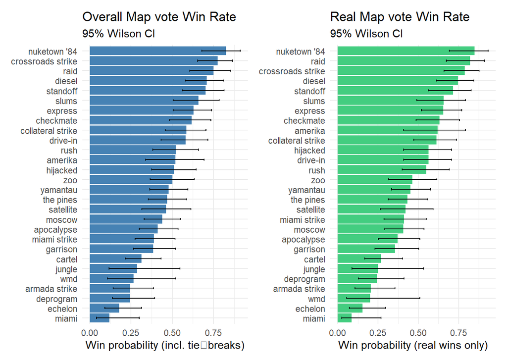

```r
#Prompts: “please Combine two plot"
 p_total + p_real + plot_layout(ncol = 2)   # side‑by‑side view
```

The model we are using is ChatGPT o3 First of all, we are using the key words in the excel documents and the project information document. We asked GPT to read the Task 1 and Task 2 content carefully and generate the visualization based on the vocabulary that should be processed in excel.

Point 1: Completeness and Scalability of Data Cleaning Strategies The Task 1 script uses an “exhaustive” manual dictionary: a sequence of mutate(ifelse()) to change misspellings to official names, line by line. This approach is extremely accurate, and will never misattribute a name as long as it is in the dictionary. However, its recall is limited by dictionary coverage - the next time a new misspelling appears (e.g., yamantou, raaid), the pipeline treats it as a “new map” and subsequent statistics are immediately distorted. The generative AI solution uses a two-stage “dictionary + fuzzy matching” approach: a small dictionary is applied to correct common misspellings, and the remaining unmatched entries are automatically merged using the Jaro-Winkler distance. Since there are only 28 entries in the map list and the names vary widely, the risk of misincorporation is low, but new misspellings in the future are automatically trapped. Thus, from a long-term maintenance point of view, the AI solution significantly reduces the burden of manual updates and is more scalable, while the manual solution is suitable only under the current data mode.

Point 2: Depth of Flat Ticket Processing and Statistical Inference We script filters out “0 to 0” ~ “4 to 4” in the cleanup phase, meaning that the only games left in the analysis are those with a “clear majority”; the “50 % vs. 50 %” mechanism that automatically awards a win in the left column is ignored. The AI solution retains the tie rows, labeled tie_win, and calculates both the “overall win rate” and the “true win rate”, allowing the reader to distinguish at a glance which maps have high win rates that rely on tie-ballooning. Further, the AI script attaches a Wilson 95% confidence interval to the win rate, reminding the decision maker that maps with small sample sizes (e.g., amerika) have a high degree of uncertainty, and that Task 1 only gives a six-decimal point estimate, which is easily misinterpreted as being “accurate to 1 in 10,000”. In terms of revealing the details of game mechanics and quantifying statistical uncertainty, the AI solution is significantly more informative.

Point 3: Code Simplicity and Maintainability The AI script puts all the misspellings into a named vector, and with stringdist_inner_join(), the complete cleaning process is realized in less than 10 lines; the rest of the steps are all connected by pipelines, the logic module is clear, and the reproduction only requires changing the data path. Although the Task 1 script is intuitive, it contains more than 40 lines of duplicate mutate() functions, and any new or undone maps have to be changed in multiple places, which is very easy to miss. Moreover, the multi-level mutate() chain is not only lengthy, but also lowers the readability of the code. The only advantage is that it doesn’t rely on external package parameters, so business colleagues can understand the mapping table even if they don’t know stringdist. If the project emphasizes interpretable results, the manual solution is more transparent. However, if the project emphasizes efficiency and reuse, The AI solution is clearly the winner.

# Task 3 (Inference)

## Research Question: How does the game type affect TotalXP after accounting for the Score?

## Data Wrangling

```r
unique(CODGames_T3$GameType)
```

```
## [1] "HC - TDM"            "HC - Kill Confirmed" "HC - Hardpoint"
## [4] "HC - Domination"     "TDM"                 "Hardpoint"
## [7] "Kill Confirmed"      "Domination"
```

```r
CODGames_T3 <- CODGames_T3 %>%
  mutate(
    GameType = str_remove(GameType, "^HC\\s*[-–]?\\s*"),

    GameType = str_to_title(str_trim(GameType)),

    GameType = case_when(
      GameType %in% c("Tdm", "Team Deathmatch") ~ "TDM",
      GameType %in% c("Hardpoint")             ~ "Hardpoint",
      TRUE                                     ~ GameType
    )) %>%
  filter(!is.na(Score))

unique(CODGames_T3$GameType)
```

```
## [1] "TDM"            "Kill Confirmed" "Hardpoint"      "Domination"
```

We checked the validity of our cleanup with *unique(CODGames_T3$GameType)*

## Data Visualization

```r
num_summary <- CODGames_T3 %>%
  summarise(across(c(Score, TotalXP),
                   list(n      = ~sum(!is.na(.x)),
                        mean   = mean,
                        sd     = sd,
                        min    = min,
                        q1     = ~quantile(.x, .25),
                        median = median,
                        q3     = ~quantile(.x, .75),
                        max    = max),
                   .names = "{.col}_{.fn}"))
print(num_summary)
```

```
##   Score_n Score_mean Score_sd Score_min Score_q1 Score_median Score_q3
## 1     808   2995.252 1398.429       100  2028.75       2807.5     3765
##   Score_max TotalXP_n TotalXP_mean TotalXP_sd TotalXP_min TotalXP_q1
## 1      9734       808     15477.72   6970.856        1935    9869.25
##   TotalXP_median TotalXP_q3 TotalXP_max
## 1        14719.5    19916.5       45310
```

```r
by_gt <- CODGames_T3 %>%
  group_by(GameType) %>%
  summarise(
    n            = n(),
    mean_Score   = mean(Score),
    sd_Score     = sd(Score),
    mean_TotalXP = mean(TotalXP),
    sd_TotalXP   = sd(TotalXP),
    .groups = "drop"
  )
print(by_gt)
```

```
## # A tibble: 4 × 6
##   GameType           n mean_Score sd_Score mean_TotalXP sd_TotalXP
##   <chr>          <int>      <dbl>    <dbl>        <dbl>      <dbl>
## 1 Domination        14      3299.     863.       17997.      6488.
## 2 Hardpoint        257      3035.    1374.       17404.      7741.
## 3 Kill Confirmed    20      2001.    1093.       10782.      4882.
## 4 TDM              517      3006.    1420.       14633.      6383.
```

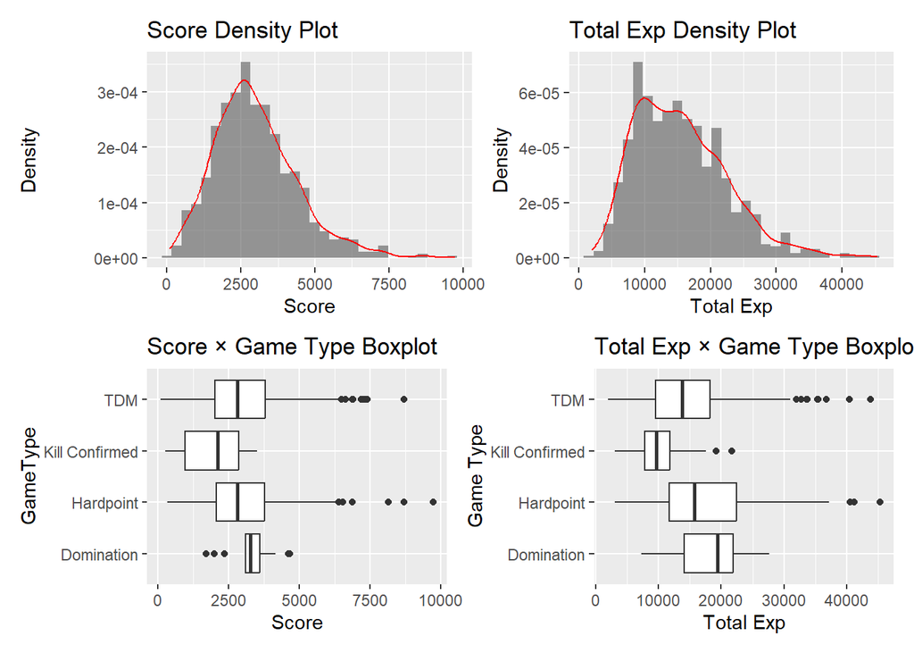

```r
p1 <- ggplot(CODGames_T3, aes(Score)) +
        geom_histogram(aes(y = ..density..), bins = 30, alpha = .6) +
        geom_density(colour = "red") +
        labs(title = "Score Density Plot", x = "Score", y = "Density")

p2 <- ggplot(CODGames_T3, aes(TotalXP)) +
        geom_histogram(aes(y = ..density..), bins = 30, alpha = .6) +
        geom_density(colour = "red") +
        labs(title = "Total Exp Density Plot", x = "Total Exp", y = "Density")


p3 <- ggplot(CODGames_T3, aes(GameType, Score)) +
        geom_boxplot() +
        labs(title = "Score × Game Type Boxplot", x = "GameType", y = "Score") +
        coord_flip()

p4 <- ggplot(CODGames_T3, aes(GameType, TotalXP)) +
        geom_boxplot() +
        labs(title = "Total Exp × Game Type Boxplot", x = "Game Type", y = "Total Exp") +
        coord_flip()



(p1 | p2) / (p3 | p4)
```

The density plots for Score and TotalXP revealed righ-skewed distributions with long tails, indicating that most players accumulated moderate amounts of score and experience, while a smaller group achieved exceptionally high values.

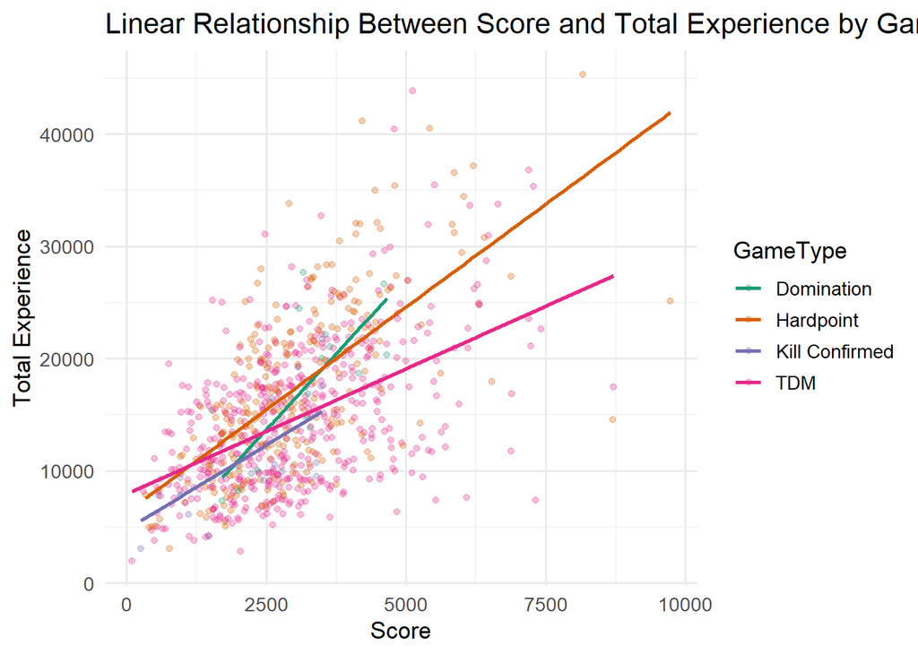

```r
ggplot(CODGames_T3, aes(x = Score, y = TotalXP, colour = GameType)) +
  geom_point(alpha = 0.3) +
  geom_smooth(method = "lm", se = F, linewidth = 1) +
  scale_colour_brewer(palette = "Dark2") +
  labs(title = "Linear Relationship Between Score and Total Experience by Game Type",
       x = "Score",
       y = "Total Experience",
       colour = "GameType", shape = "GameType") +
  theme_minimal(base_size = 13) +
  theme()
```

```r
slopes <- CODGames_T3 %>%
  group_by(GameType) %>%
  summarise(slope = coef(lm(TotalXP ~ Score))[2])

slopes
```

```
## # A tibble: 4 × 2
##   GameType       slope
##   <chr>          <dbl>
## 1 Domination      5.41
## 2 Hardpoint       3.66
## 3 Kill Confirmed  3.00
## 4 TDM             2.23
```

This scatterplot visualizes the linear relationship between Score and TotalXP, with four colored fitted lines to distinguish between different Game Types. At the same time, the efficiency of the “experience/score” conversion varies from mode to mode. The slope is roughly in the order of Domination > Hardpoint > Kill Confirmed > TDM. TDM gives the least experience for the same score.

## Modeling Multiple Linear Models

```r
model1 <- lm(TotalXP ~ Score + GameType, data = CODGames_T3)
summary(model1)


model2 <- lm(TotalXP ~ Score * GameType, data = CODGames_T3)
summary(model2)

anova(model1, model2)
```

```r
tidy(model1) %>%
  mutate(across(where(is.numeric), round, 3)) %>%
  kbl(caption = "Model 1: TotalXP ~ Score + GameType") %>%
  kable_classic(full_width = F, html_font = "Times New Roman")
```

Model 1: TotalXP ~ Score + GameType

| term | estimate | std.error | statistic | p.value |
| --- | --- | --- | --- | --- |
| (Intercept) | 9072.591 | 1592.560 | 5.697 | 0.000 |
| Score | 2.705 | 0.144 | 18.768 | 0.000 |
| GameTypeHardpoint | 121.761 | 1561.226 | 0.078 | 0.938 |
| GameTypeKill Confirmed | -3703.173 | 1990.539 | -1.860 | 0.063 |
| GameTypeTDM | -2570.437 | 1540.934 | -1.668 | 0.096 |

```r
tidy(model2) %>%
  mutate(across(where(is.numeric), round, 3)) %>%
  kbl(caption = "Model 2: TotalXP ~ Score * GameType (with interaction)") %>%
  kable_classic(full_width = F, html_font = "Times New Roman")
```

Model 2: TotalXP ~ Score * GameType (with interaction)

| term | estimate | std.error | statistic | p.value |
| --- | --- | --- | --- | --- |
| (Intercept) | 141.168 | 6140.010 | 0.023 | 0.982 |
| Score | 5.413 | 1.805 | 2.999 | 0.003 |
| GameTypeHardpoint | 6153.288 | 6198.660 | 0.993 | 0.321 |
| GameTypeKill Confirmed | 4637.698 | 6695.983 | 0.693 | 0.489 |
| GameTypeTDM | 7788.913 | 6167.196 | 1.263 | 0.207 |
| Score:GameTypeHardpoint | -1.752 | 1.823 | -0.961 | 0.337 |
| Score:GameTypeKill Confirmed | -2.412 | 2.155 | -1.119 | 0.263 |
| Score:GameTypeTDM | -3.182 | 1.813 | -1.755 | 0.080 |

```r
anova(model1, model2) %>%
  mutate(across(where(is.numeric), round, 3)) %>%
  kbl(caption = "ANOVA: Model Comparison (F-test for nested models)") %>%
  kable_classic(full_width = F, html_font = "Times New Roman")
```

ANOVA: Model Comparison (F-test for nested models)

| Res.Df | RSS | Df | Sum of Sq | F | Pr(>F) |
| --- | --- | --- | --- | --- | --- |
| 803 | 25970535492 | NA | NA | NA | NA |
| 800 | 25221513666 | 3 | 749021825 | 7.919 | 0 |

## Conclusion

Because the interaction model was significantly better than the main effects-only model, Model 2 is recommended as the final answer:

Therefore, Model 2 is selected as the final model for inference.

In this model, Score remains the strongest predictor of TotalXP. However, the conversion efficiency from Score to TotalXP varies by GameType, as captured by the interaction terms:

Among all predictors, Score is the only statistically significant predictor of TotalXP p = 0.003, confirming its role as the primary driver of experience gain. While game modes show different baseline intercepts, these are not statistically significant and thus not strongly interpretable.

The interaction term for TDM is the most notable, with a nearly significant negative effect on the Score–Experience slope p ≈ 0.08, indicating that players in TDM gain fewer XP per unit of Score than in other modes. This supports the conclusion that game type influences TotalXP mainly by altering the “conversion rate” from Score, not by shifting absolute XP levels.

# Task 4 (Prediction)

## Research Question: Is KDR (kill/death ratio) a significant predictor in predicting game mode?

## Random Forest

```r
# Calculate K/D Ratio
games_model <- CODGames_T3 %>%
  filter(Deaths > 0) %>%
  mutate(KDR = Eliminations / Deaths) %>%
  dplyr::select(GameType, KDR, Score, Damage, TotalXP) %>%
  drop_na()


set.seed(123)
train_ind <- sample(1:nrow(games_model), floor(0.8 * nrow(games_model)))
Train <- games_model[train_ind, ]
Validation <- games_model[-train_ind, ]
set.seed(NULL)

Train$GameType <- as.factor(Train$GameType)
Validation$GameType <- as.factor(Validation$GameType)

Validation$GameType <- factor(Validation$GameType, levels = levels(Train$GameType))

# Random forest model
rf_model <- randomForest(GameType ~ ., data = Train, ntree = 500, importance = TRUE)

# Predict
rf_preds <- predict(rf_model, newdata = Validation)

rf_model$importance
```

```
##         Domination    Hardpoint Kill Confirmed        TDM MeanDecreaseAccuracy
## KDR     0.04031905  0.018273731   0.0156691198 0.14709741           0.10115501
## Score   0.03278175  0.017460039  -0.0009825397 0.11204616           0.07799166
## Damage  0.02475714  0.110787835   0.0151278499 0.16156725           0.13900557
## TotalXP 0.03146667 -0.004055863   0.0140564214 0.05261319           0.03336590
##         MeanDecreaseGini
## KDR             70.85732
## Score           70.59595
## Damage         107.14265
## TotalXP         67.79634
```

We created a new variable by combining the variables Eliminations and Deaths, using mutate() to compute the Kill/Death Ratio (KDR) as Eliminations divided by Deaths. A value greater than 1 indicates that the player had more eliminations than deaths; a value less than 1 indicates more deaths than eliminations; and a value equal to 1 indicates an equal number of eliminations and deaths.

Using this new KDR variable along with other predictors such as Score, Damage, and TotalXP, we attempted to predict the game mode the player was participating in. We set a random seed for reproducibility and split the dataset into an 80/20 training/validation set.

KDR also showed strong predictive power, especially in MeanDecreaseAccuracy, which means that players’ relative efficiency in eliminating enemies over being eliminated is informative in distinguishing between game modes.

## Knn

```r
train_X <- as.matrix(Train[, c("KDR", "Score", "Damage", "TotalXP")])
test_X <- as.matrix(Validation[, c("KDR", "Score", "Damage", "TotalXP")])
train_y <- Train$GameType

# Run KNN
knn_preds <- knn(train = train_X, test = test_X, cl = train_y, k = 5)

# Evaluate
confusionMatrix(knn_preds, Validation$GameType)
```

```
## Confusion Matrix and Statistics
##
##                 Reference
## Prediction       Domination Hardpoint Kill Confirmed TDM
##   Domination              0         0              0   0
##   Hardpoint               0        28              0  26
##   Kill Confirmed          0         0              0   0
##   TDM                     2        25              4  77
##
## Overall Statistics
##
##                Accuracy : 0.6481
##                  95% CI : (0.5693, 0.7214)
##     No Information Rate : 0.6358
##     P-Value [Acc > NIR] : 0.406
##
##                   Kappa : 0.2467
##
##  Mcnemar's Test P-Value : NA
##
## Statistics by Class:
##
##                      Class: Domination Class: Hardpoint Class: Kill Confirmed
## Sensitivity                    0.00000           0.5283               0.00000
## Specificity                    1.00000           0.7615               1.00000
## Pos Pred Value                     NaN           0.5185                   NaN
## Neg Pred Value                 0.98765           0.7685               0.97531
## Prevalence                     0.01235           0.3272               0.02469
## Detection Rate                 0.00000           0.1728               0.00000
## Detection Prevalence           0.00000           0.3333               0.00000
## Balanced Accuracy              0.50000           0.6449               0.50000
##                      Class: TDM
## Sensitivity              0.7476
## Specificity              0.4746
## Pos Pred Value           0.7130
## Neg Pred Value           0.5185
## Prevalence               0.6358
## Detection Rate           0.4753
## Detection Prevalence     0.6667
## Balanced Accuracy        0.6111
```

The second method we used was k-Nearest Neighbors (kNN) to predict GameType using the variables KDR, Score, Damage, and TotalXP. We created the matrices train_X (containing the input features), train_Y (the target labels), and test_X (the features from the validation set). The model was run with k = 5, and predictions were generated using the knn() function with train_Y as the class labels.

The predictions stored in knn_pred were then evaluated using a confusion matrix, comparing the predicted game modes to the true values from the validation set. The model achieved an overall accuracy of approximately 64.8%, which is a moderately good performance for this type of classification task.

However, the confusion matrix reveals certain discrepancies. In particular, the model struggled to correctly classify underrepresented classes such as Domination and Kill Confirmed, both of which have relatively few samples in the dataset. In contrast, it performed reasonably well on more frequent classes such as Team Deathmatch (TDM) and Hardpoint.

This discrepancy highlights the effect of class imbalance in the training data: the model tends to perform better on the majority classes and worse on the minority ones. This is a known limitation of kNN, as it relies heavily on the local structure and density of the training data. Addressing this imbalance—through techniques such as oversampling, class weighting, or stratified sampling—may further improve performance for the less frequent game modes.

## Naive Bayes

```r
# Naive Bayes with ALL predictors
nb_full <- naiveBayes(GameType ~ KDR + Score + Damage + TotalXP, data = Train)
nb_full_pred <- predict(nb_full, newdata = Validation)
confusionMatrix(nb_full_pred, Validation$GameType)
```

```
## Confusion Matrix and Statistics
##
##                 Reference
## Prediction       Domination Hardpoint Kill Confirmed TDM
##   Domination              0         0              0   0
##   Hardpoint               0        22              0  20
##   Kill Confirmed          0         0              0   0
##   TDM                     2        31              4  83
##
## Overall Statistics
##
##                Accuracy : 0.6481
##                  95% CI : (0.5693, 0.7214)
##     No Information Rate : 0.6358
##     P-Value [Acc > NIR] : 0.406
##
##                   Kappa : 0.2079
##
##  Mcnemar's Test P-Value : NA
##
## Statistics by Class:
##
##                      Class: Domination Class: Hardpoint Class: Kill Confirmed
## Sensitivity                    0.00000           0.4151               0.00000
## Specificity                    1.00000           0.8165               1.00000
## Pos Pred Value                     NaN           0.5238                   NaN
## Neg Pred Value                 0.98765           0.7417               0.97531
## Prevalence                     0.01235           0.3272               0.02469
## Detection Rate                 0.00000           0.1358               0.00000
## Detection Prevalence           0.00000           0.2593               0.00000
## Balanced Accuracy              0.50000           0.6158               0.50000
##                      Class: TDM
## Sensitivity              0.8058
## Specificity              0.3729
## Pos Pred Value           0.6917
## Neg Pred Value           0.5238
## Prevalence               0.6358
## Detection Rate           0.5123
## Detection Prevalence     0.7407
## Balanced Accuracy        0.5894
```

```r
# With KDR Only
nb_kdr <- naiveBayes(GameType ~ KDR, data = Train)
nb_kdr_pred <- predict(nb_kdr, newdata = Validation)
confusionMatrix(nb_kdr_pred, Validation$GameType)
```

```
## Confusion Matrix and Statistics
##
##                 Reference
## Prediction       Domination Hardpoint Kill Confirmed TDM
##   Domination              0         0              0   0
##   Hardpoint               0         0              0   0
##   Kill Confirmed          0         0              0   0
##   TDM                     2        53              4 103
##
## Overall Statistics
##
##                Accuracy : 0.6358
##                  95% CI : (0.5567, 0.7099)
##     No Information Rate : 0.6358
##     P-Value [Acc > NIR] : 0.5354
##
##                   Kappa : 0
##
##  Mcnemar's Test P-Value : NA
##
## Statistics by Class:
##
##                      Class: Domination Class: Hardpoint Class: Kill Confirmed
## Sensitivity                    0.00000           0.0000               0.00000
## Specificity                    1.00000           1.0000               1.00000
## Pos Pred Value                     NaN              NaN                   NaN
## Neg Pred Value                 0.98765           0.6728               0.97531
## Prevalence                     0.01235           0.3272               0.02469
## Detection Rate                 0.00000           0.0000               0.00000
## Detection Prevalence           0.00000           0.0000               0.00000
## Balanced Accuracy              0.50000           0.5000               0.50000
##                      Class: TDM
## Sensitivity              1.0000
## Specificity              0.0000
## Pos Pred Value           0.6358
## Neg Pred Value              NaN
## Prevalence               0.6358
## Detection Rate           0.6358
## Detection Prevalence     1.0000
## Balanced Accuracy        0.5000
```

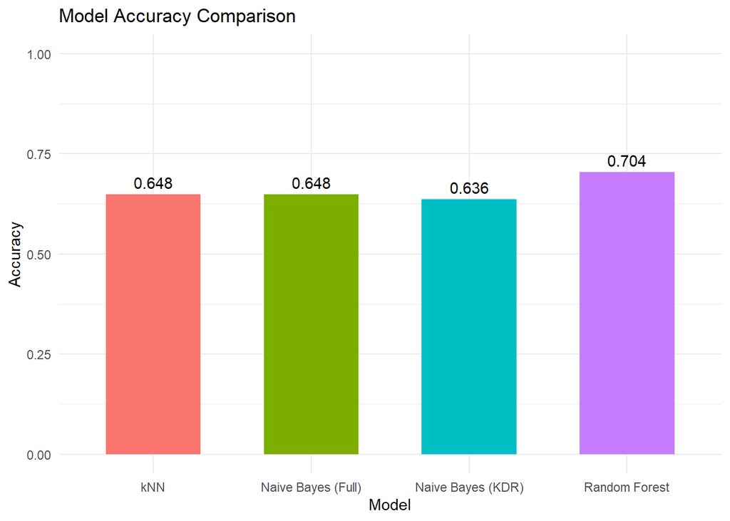

```r
# Naive Bayes Full
nb_full_cm <- confusionMatrix(nb_full_pred, Validation$GameType)
acc_nb_full <- nb_full_cm$overall['Accuracy']

# Naive Bayes KDR
nb_kdr_cm <- confusionMatrix(nb_kdr_pred, Validation$GameType)
acc_nb_kdr <- nb_kdr_cm$overall['Accuracy']

# KNN
knn_cm <- confusionMatrix(knn_preds, Validation$GameType)
acc_knn <- knn_cm$overall['Accuracy']

# Random Forest
rf_cm <- confusionMatrix(rf_preds, Validation$GameType)
acc_rf <- rf_cm$overall['Accuracy']

model_results <- data.frame(
  Model = c("Naive Bayes (Full)", "Naive Bayes (KDR)", "kNN", "Random Forest"),
  Accuracy = c(acc_nb_full, acc_nb_kdr, acc_knn, acc_rf)
)


ggplot(model_results, aes(x = Model, y = Accuracy, fill = Model)) +
  geom_bar(stat = "identity", width = 0.6) +
  geom_text(aes(label = round(Accuracy, 3)), vjust = -0.5) +
  ylim(0, 1) +
  theme_minimal() +
  labs(title = "Model Accuracy Comparison", y = "Accuracy", x = "Model") +
  theme(legend.position = "none")
```

## Conclusions

In kNN, including KDR alongside other features resulted in a validation accuracy of around 64.8%, indicating its value when combined with Score and Damage.

In Naive Bayes, KDR alone failed to differentiate between game modes, predicting only the majority class (TDM). However, its performance improved slightly when used with additional features, though still limited due to violation of Naive Bayes’ independence assumptions.

KDR reflects a player’s combat efficiency and provides useful discriminatory power, especially in ensemble models like Random Forest. While it should not be used in isolation, it is a valuable component in multi-variable classification models for predicting game mode.